# Titanic

I've choose this dataset for the visualizations Project to communicate data findings. this dataset have records of the passengers who were in the Titanic backthen, it's from kaggle and it's manly for machine learning. but i find it very neat and will be good for the visualizations purpurses of this project as i manged to get intersiting qustions as listd below

# Questions

- Did most people surived or not ?
- What factors affects the chance of survivng ?
- Do higher classes have higher chances of surviving ?
- Who have more chance of survivng, men or women ?
- Do solo travellers have less chances of survivng ?
- Do yenger people have more chance of survivng ?
- Do wealthier people have more chance of surviving ?

## Did most people surived or not ?

it turned out that most people didn't survived, 424 didn't and 288 did.

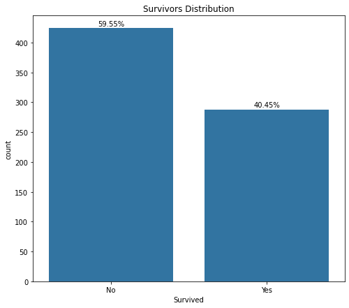

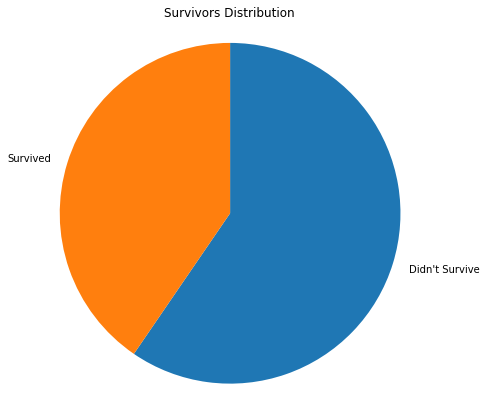

## Age Distribution

The majority are between 20 and 40

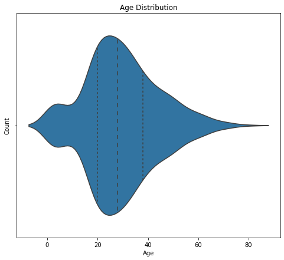

## Fare Distribution

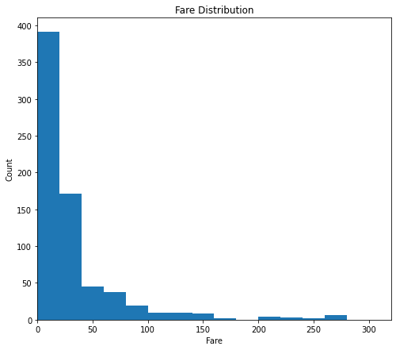

## Class Distribution

Majority of people are from class 3 (expected)

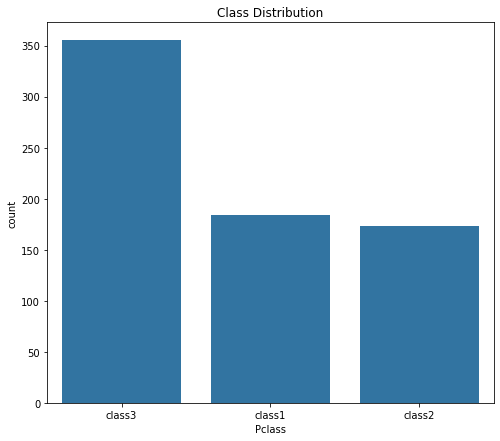

## Number of siblings / spouses aboard the Titanic Distribution

majority doesn't have siblings

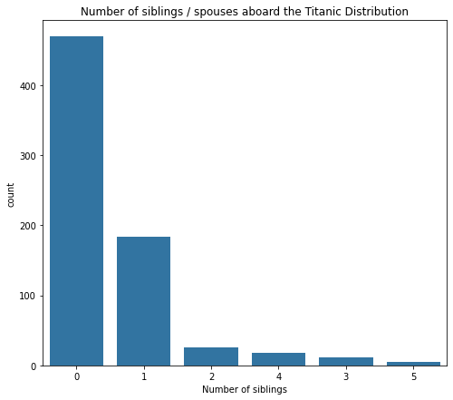

## Does higher classes have higher chances of surviving ?

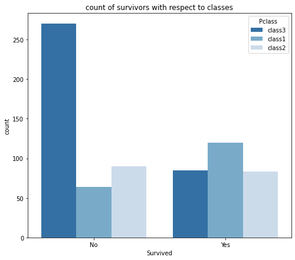

- we can see that the highst class class1 has the highst surviving rate, while the lowest class class3 has the lowest survivng rate
- majority of people in class3 didn't survived

## Who have more chance of survivng, men or women ?

okay, this has surprised me. it seems like women have higher chance of survivng.

most men didn't make it out alive :'

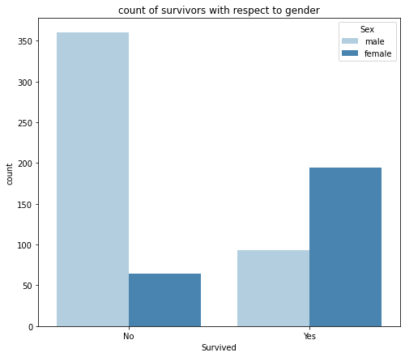

## Does solo travellers have less chances of survivng ?

solo travellers have the most surviving records and not surviving too. 60% of survivors were solo travellers, 69.81% of people who didn't make it out alive were solo travellers.

but only 40.5% total survived, and 59.5% died. **so yes, solo travellers have less chances of survivng**

having family

```
posx and posy should be finite values
posx and posy should be finite values
```

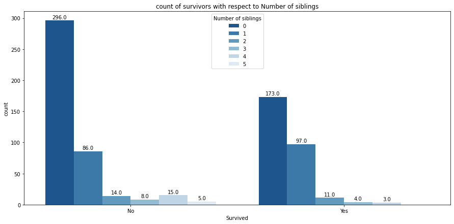

```
posx and posy should be finite values
posx and posy should be finite values
```

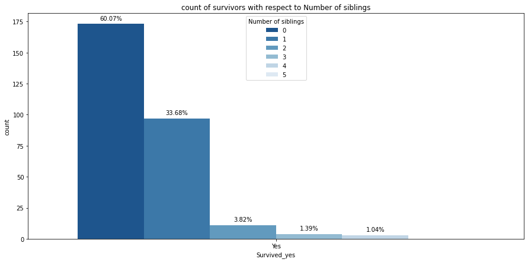

**60% of survivors were solo travellers**

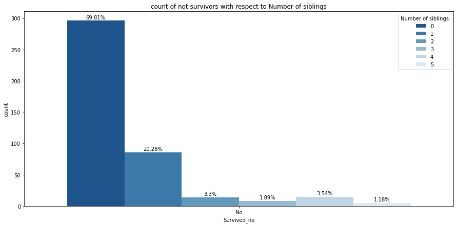

**we can see now that 60% of survivors were solo travellers, and 69.81% of people who didn't make it out alive were solo travellers**

## Do yenger people have more chance of survivng ?

yes

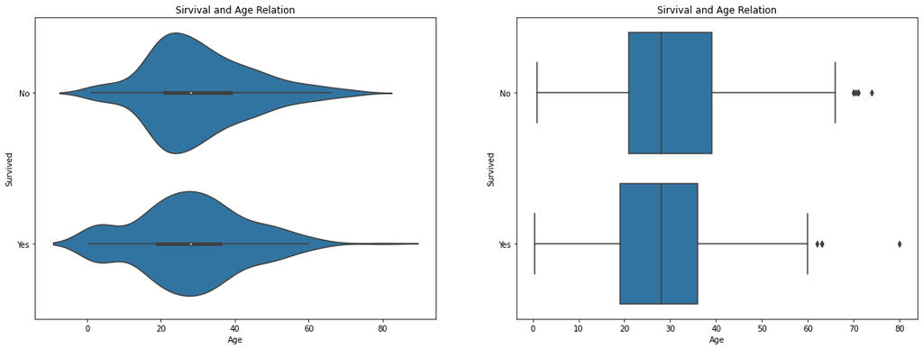

## Do wealthier people have more chance of surviving ?

yes, as wealthier people are in higher classes

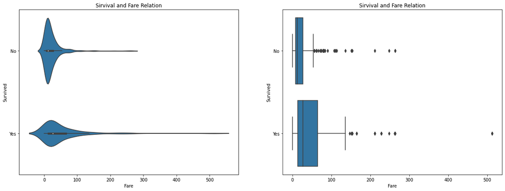

**Yes wealthier people have more chance of surviving, as wealthier people are in higher classes**

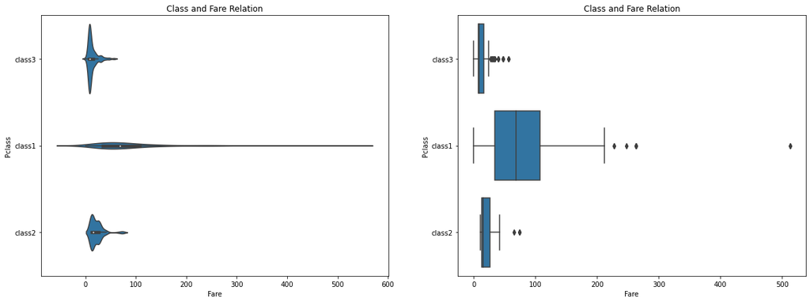

## Age and Fare heat map

majority of people are with low badjet and with ages between 17 and 35

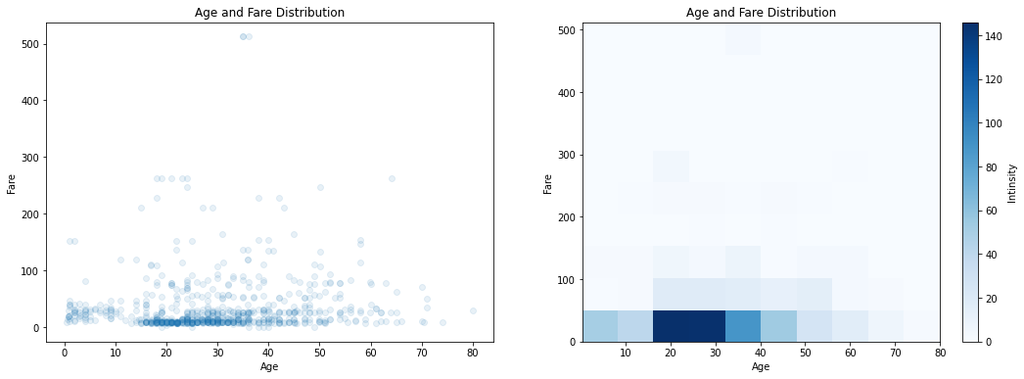

## Number of Siblings with Respect to Age and Fare Distributions

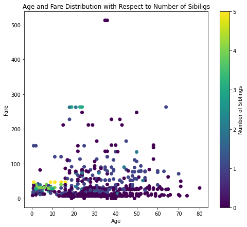

## Age and Fare Distibution with respect to Gender and Survival

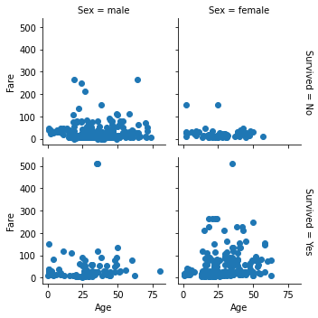